# 第 8 章 凸集

#### 8.0.0.1 直线

**Definition 8.1**. 设$x_1,x_2\in\mathbb{R}^{n}$且$x_1\ne x_2$。若$\theta\in[0,1]$，称所有满足形式：

$$\begin{equation*}
y=\theta x_1+(1-\theta)x_2
\end{equation*}$$

的点$y$构成的集合为线段（line segment）。若$\theta\in\mathbb{R}^{}$，称所有满足上述形式的点$y$构成的集合为直线（line）。

**note 8.1**. 上述形式等价于：

$$\begin{equation*}
y=x_2+\theta(x_1-x_2)
\end{equation*}$$

这给出了另一种直观：$y$是基$x_2$和被$\theta$缩放的方向$x_1-x_2$的和。

#### 8.0.0.2 凸集

**Definition 8.2**. 设$E\subseteq\mathbb{R}^{n}$。若对于任意不同的$x_1,x_2\in E$，由$x_1,x_2$确定的线段都在$E$中，则称$E$是凸集（convex set）。

**Definition 8.3**. 设$n\in\mathbb{N}^+$，$\theta_1, \theta_2, \dots, \theta_{n}\geqslant0$且$\sum\limits_{i=1}^{n}\theta_i=1$，$x_1, x_2, \dots, x_{n}\in\mathbb{R}^{n}$。称：

$$\begin{equation*}
\theta_1x_1+\theta_2x_2+\cdots+\theta_nx_n
\end{equation*}$$

为$x_1, x_2, \dots, x_{n}$构成的一个凸组合（convex combination）。

**Definition 8.4**. 设$E\subseteq\mathbb{R}^{n}$。定义：

$$\begin{equation*}
\left\{\sum_{i=1}^{n}\theta_ix_i:x_i\in E,\;\theta_i\geqslant0,\;\sum_{i=1}^{n}\theta_i=1,\;n\in\mathbb{N}^+\right\}
\end{equation*}$$

为$E$的凸包（convex hull），记作$\operatorname{Conv}(E)$。

[figure not shown]

凸集、非凸集与凸包的二维几何结构。

**Property 8.0.1**. 设$E\subseteq\mathbb{R}^{n}$。凸集具有如下性质：

1. $E$是凸集当且仅当$E$中任意有限个元素的凸组合都在$E$中；
2. $E$的凸包是包含$E$的最小凸集；
3. 凸集的交集是凸集；
4. 设$\alpha\in\mathbb{R}^{n},\;a\in\mathbb{R}^{}$，$E$是凸集，则$aE=\{ax:x\in E\}$和$E+\alpha=\{x+\alpha:x\in E\}$也是凸集；
5. 设$E_1,E_2$是凸集，则$E_1+E_1=\{x+y:x\in E_1,\;y\in E_2\}$也是凸集；
6. 设$E_1,E_2$是凸集，则$\{(x,y_1+y_2):(x,y_1)\in E_1,\;(x,y_2)\in E_2\}$也是凸集；
7. 若$E$是凸集，则$\{x_1\in\mathbb{R}^{m}:(x_1,x_2)\in E,\;m\in\mathbb{N}^+,\;m\leqslant n\}$也是凸集，即凸集的投影是凸集。

*证明*. (1)**必要性：**当$n=2$时，由凸集的定义可知$E$中任意$2$个元素的凸组合都在$E$中。假设结论对$n-1$成立，下面证明对$n$个也成立。

任取$\theta_1, \theta_2, \dots, \theta_{n}\geqslant0$且$\sum\limits_{i=1}^{n}\theta_i=1$，$x_1, x_2, \dots, x_{n}\in E$，则：

$$\begin{equation*}
\sum_{i=1}^{n}\theta_ix_i=\sum_{i=1}^{n-1}\theta_ix_i+\theta_nx_n=\sum_{i=1}^{n-1}\theta_ix_i+\left(1-\sum_{i=1}^{n-1}\theta_i\right)x_i
\end{equation*}$$

若$\sum\limits_{i=1}^{n-1}\theta_i=0$，则上式退化为$x_n$，结论成立。若$\sum\limits_{i=1}^{n-1}\theta_i\ne0$，则：

$$\begin{equation*}
y=\sum_{i=1}^{n-1}\frac{\theta_i}{\sum\limits_{j=1}^{n-1}\theta_j}x_i
\end{equation*}$$

是关于$x_1, x_2, \dots, x_{n-1}$的一个凸组合，由归纳假设可知$y\in E$。变形可得：

$$\begin{equation*}
\sum_{i=1}^{n}\theta_ix_i=\sum_{i=1}^{n-1}\theta_ix_i+\left(1-\sum_{i=1}^{n-1}\theta_i\right)x_i=\sum\limits_{j=1}^{n-1}\theta_jy+\left(1-\sum_{i=1}^{n-1}\theta_i\right)x_i\in E
\end{equation*}$$

必要性得证。

**充分性：**任意有限个包含$2$个。

(2)由(1)立即可得。

(3)任取指标集$I$和凸集$C_i,i\in I$，令$C=\underset{i\in I}{\overset{}{\cap}}C_i$。任取$x_1,x_2\in C$和$\theta\geqslant0$，则$x_1,x_2\in C_i$。因为$C_i$是凸集，所以$\theta x_1+(1-\theta)x_2\in C_i$，于是$\theta x_1+(1-\theta)x_2\in C$，$C$是凸集。

(4)(5)(6)(7)利用凸集的定义可直接得到证明，略去。 ◻

#### 8.0.0.3 仿射集

**Definition 8.5**. 设$E\subseteq\mathbb{R}^{n}$。若对于任意不同的$x_1,x_2\in E$，由$x_1,x_2$确定的直线都在$E$中，则称$E$是仿射集（affine set）。

**Definition 8.6**. 设$n\in\mathbb{N}^+$，$\theta_1, \theta_2, \dots, \theta_{n}\in\mathbb{R}^{}$且$\sum\limits_{i=1}^{n}\theta_i=1$，$x_1, x_2, \dots, x_{n}\in\mathbb{R}^{n}$。称：

$$\begin{equation*}
\theta_1x_1+\theta_2x_2+\cdots+\theta_nx_n
\end{equation*}$$

为$x_1, x_2, \dots, x_{n}$构成的一个仿射组合（affine combination）。

**Definition 8.7**. 设$E\subseteq\mathbb{R}^{n}$。定义：

$$\begin{equation*}
\left\{\sum_{i=1}^{n}\theta_ix_i:x_i\in E,\;\theta_i\in\mathbb{R}^{},\;\sum_{i=1}^{n}\theta_i=1,\;n\in\mathbb{N}^+\right\}
\end{equation*}$$

为$E$的仿射包（affine hull），记作$\operatorname{Aff}(E)$。

[figure not shown]

仿射集是子空间的平移。它不必经过原点，并且沿方向子空间*V*的正、负方向无限延伸。

**Property 8.0.2**. 设$E\subseteq\mathbb{R}^{n}$。仿射集具有如下性质：

1. $E$是仿射集当且仅当$E$中任意有限个元素的仿射组合都在$E$中；
2. $E$是仿射集当且仅当存在一个$\mathbb{R}^{n}$的子空间$V$，使得$E=\{x+x_0:x\in V,\;x_0\in E\}$，并且表达式与$x_0$的选择无关；
3. $E$的仿射包是包含$E$的最小仿射集；
4. 仿射集是凸集；

*证明*. (1)完全类似于性质 8.0.1(1)。

(2)**必要性：**设$E$是仿射集，任取$x_0\in E$，令$V=\{x-x_0:x\in E\}$，则$E=\{x+x_0:x\in V,\;x_0\in E\}$。

任取$\alpha,\beta\in\mathbb{R}^{}$和$x_1,x_2\in V$，则：

$$\begin{equation*}
\alpha x_1+\beta x_2+x_0=\alpha(x_1+x_0)+\beta(x_2+x_0)+(1-\alpha-\beta)x_0\in E
\end{equation*}$$

于是$\alpha x_1+\beta x_2\in V$。由定理 1.5可知$V$是子空间。

取不同于$x_0$的$x_1\in E$构成集合$V'=\{x-x_1:x\in C\}$。任取$V'$中的元素$\alpha=x-x_1$，则$\alpha=x+x_1-x_0$是$x,x_1,x_0$构成的一个仿射组合，于是$\alpha\in V$。由$\alpha$的任意性可知$V'\subseteq V$。同理可得$V\subseteq V'$，于是有$V=V'$，即表达式与$x_0$的选择无关。

**充分性：**任取$E$中不同的两点$x_1+x_0,x_2+x_0$和$\theta\in\mathbb{R}^{}$，有：

$$\begin{equation*}
\theta(x_1+x_0)+(1-\theta)(x_2+x_0)=\theta x_1+(1-\theta)x_2+x_0
\end{equation*}$$

因为$V$是子空间，由定理 1.5可知$\theta x_1+(1-\theta)x_2\in V$，所以$\theta x_1+(1-\theta)x_2+x_0\in E$。由$x_1+x_0,x_2+x_0$和$\theta$的任意性可知$E$是仿射集。

(3)由(1)立即可得。

(4)由定义立即可得。 ◻

#### 8.0.0.4 锥

**Definition 8.8**. 设$E\subseteq\mathbb{R}^{n}$。若对于任意的$x\in E$和$\theta\geqslant0$，有$\theta x\in E$，则称$E$是锥（cone）。若锥$E$还满足对任意的$x_1,x_2\in E$和$\theta_1,\theta_2\geqslant0$有$\theta_1x_1+\theta_2x_2\in E$，则称$E$为凸锥（convex cone）。

**Definition 8.9**. 设$n\in\mathbb{N}^+$，$\theta_1, \theta_2, \dots, \theta_{n}\geqslant0$，$x_1, x_2, \dots, x_{n}\in\mathbb{R}^{n}$。称：

$$\begin{equation*}
\theta_1x_1+\theta_2x_2+\cdots+\theta_nx_n
\end{equation*}$$

为$x_1, x_2, \dots, x_{n}$构成的一个锥组合（Conic combination）。

**Definition 8.10**. 设$E\subseteq\mathbb{R}^{n}$。定义：

$$\begin{equation*}
\left\{\sum_{i=1}^{n}\theta_ix_i:x_i\in E,\;\theta_i\geqslant0,\;n\in\mathbb{N}^+\right\}
\end{equation*}$$

为$E$的锥包（conic hull），记作$\operatorname{Cone}(E)$。

[figure not shown]

锥只要求沿每条射线对非负缩放封闭；凸锥还要求对加法封闭，因此包含两条射线之间的全部非负线性组合。

**Property 8.0.3**. 设$E\subseteq\mathbb{R}^{n}$。锥具有如下性质：

1. $E$是锥包当且仅当$E$中任意有限个元素的锥组合都在$E$中；
2. $E$的锥包是包含$E$的最小锥；

*证明*. (1)完全类似于性质 8.0.1(1)。

(2)由(1)立即可得。 ◻

#### 8.0.0.5 超平面与半空间

**Definition 8.11**. 设$a\in\mathbb{R}^{n},\;b\in\mathbb{R}^{}$。称$\{x\in\mathbb{R}^{n}:a^{\top}x=b\}$为超平面（hyperplane），$\{x\in\mathbb{R}^{n}:a^{\top}x\leqslant b\}$为闭半空间（halfspace），$\{x\in\mathbb{R}^{n}:a^{\top}x< b\}$为开半空间。

**Property 8.0.4**. 超平面与半空间具有如下性质：

1. 超平面是仿射集；
2. 半空间是凸集；

*证明*. (1)任取超平面$\{x\in\mathbb{R}^{n}:a^{\top}x=b\}$和其中任意两点$x_1,x_2$，再任取$\theta\in\mathbb{R}^{}$，有：

$$\begin{equation*}
a^{\top}[\theta x_1+(1-\theta)x_2]=\theta b+(1-\theta)b=b
\end{equation*}$$

所以$\theta x_1+(1-\theta)x_2\in\{x\in\mathbb{R}^{n}:a^{\top}x=b\}$，超平面是仿射集。

(2)任取闭半空间$\{x\in\mathbb{R}^{n}:a^{\top}x\leqslant b\}$和其中任意两点$x_1,x_2$，再任取$\theta\geqslant0$，有：

$$\begin{equation*}
a^{\top}[\theta x_1+(1-\theta)x_2]\leqslant\theta b+(1-\theta)b=b
\end{equation*}$$

所以$\theta x_1+(1-\theta)x_2\in\{x\in\mathbb{R}^{n}:a^{\top}x\leqslant b\}$，闭半空间是凸集。开半空间同理可得。 ◻

#### 8.0.0.6 多面体

**Definition 8.12**. 设$A\in M_{m\times n}(\mathbb{R}^{}),\;b\in\mathbb{R}^{n},\;C\in M_{p\times q}(\mathbb{R}^{}),\;d\in\mathbb{R}^{q}$。称$\{x\in\mathbb{R}^{n}:Ax\leqslant b,\;Cx=d\}$为多面体（polyhedron）。

**Property 8.0.5**. 多面体是凸集。

*证明*. 由性质 8.0.1(3)、性质 8.0.4(1)、性质 8.0.2(4)和性质 8.0.4(2)立即可得。 ◻

#### 8.0.0.7 球与椭球

**Definition 8.13**. 设$||\cdot||$是$\mathbb{R}^{n}$上的一个范数，$x_c\in\mathbb{R}^{n},\;r\in\mathbb{R}^{}$。称$\{x\in\mathbb{R}^{n}:||x-x_c||\leqslant r\}$为球（ball）。

**Definition 8.14**. 设$P\in M_{n}(\mathbb{R}^{})$是正定矩阵，$x_c\in\mathbb{R}^{n}$。由定理 2.17(6)可得$P$的可逆性，称$\{x\in\mathbb{R}^{n}:(x-x_c)^{\top}P^{-1}(x-x_c)\leqslant1\}$为椭球（ellipsoid）。

**Property 8.0.6**. 球与椭球具有如下性质：

1. 球是凸集；
2. 椭球$\{x\in\mathbb{R}^{n}:(x-x_c)^{\top}P^{-1}(x-x_c)\leqslant1\}$等价于$\{x_c+P^{\frac{1}{2}}u:u\in\mathbb{R}^{n},\;||u||_2\leqslant1\}$，由$P$的正定性可得$P^{\frac{1}{2}}$的存在性；
3. 椭球是凸集；

*证明*. (1)任取球$\{x\in\mathbb{R}^{n}:||x-x_c||\leqslant r\}$和其中任意两点$x_1,x_2$，再任取$\theta\geqslant0$，有：

$$\begin{equation*}
||\theta x_1+(1-\theta)x_2-x_c||=||\theta(x_1-x_c)+(1-\theta)(x_2-x_c)||\leqslant\theta||x_1-x_c||+(1-\theta)||x_2-x_c||\leqslant\theta r+(1-\theta)r=r
\end{equation*}$$

所以$\theta x_1+(1-\theta)x_2\in\{x\in\mathbb{R}^{n}:||x-x_c||\leqslant r\}$，球是凸集。

(2)任取$x\in\{x_c+P^{\frac{1}{2}}u:u\in\mathbb{R}^{n},\;||u||_2\leqslant1\}$，由性质 2.1.2(4)可得：

$$\begin{equation*}
(x-x_c)^{\top}P^{-1}(x-x_c)=(P^{\frac{1}{2}}u)^{\top}P^{-1}P^{\frac{1}{2}}u=||u||_2\leqslant1
\end{equation*}$$

所以$\{x_c+P^{\frac{1}{2}}u:u\in\mathbb{R}^{n},\;||u||_2\leqslant1\}\subseteq\{x\in\mathbb{R}^{n}:(x-x_c)^{\top}P^{-1}(x-x_c)\leqslant1\}$。

任取$x\in\{x\in\mathbb{R}^{n}:(x-x_c)^{\top}P^{-1}(x-x_c)\leqslant1\}$。由$P$的正定性可得$P^{-\frac{1}{2}}$的存在性，取$u=P^{-\frac{1}{2}}(x-x_c)$，根据性质 2.1.2(4)可得：

$$\begin{equation*}
||u||_2=[P^{-\frac{1}{2}}(x-x_c)]^{\top}P^{-\frac{1}{2}}(x-x_c)=(x-x_c)^{\top}P^{-1}(x-x_c)\leqslant1
\end{equation*}$$

所以$\{x\in\mathbb{R}^{n}:(x-x_c)^{\top}P^{-1}(x-x_c)\leqslant1\}\subseteq\{x_c+P^{\frac{1}{2}}u:u\in\mathbb{R}^{n},\;||u||_2\leqslant1\}$。

综上，$\{x\in\mathbb{R}^{n}:(x-x_c)^{\top}P^{-1}(x-x_c)\leqslant1\}=\{x_c+P^{\frac{1}{2}}u:u\in\mathbb{R}^{n},\;||u||_2\leqslant1\}$。

(3)任取椭球$\{x\in\mathbb{R}^{n}:(x-x_c)^{\top}P^{-1}(x-x_c)\leqslant1\}$和其中任意两点$x_1=x_c+P^{\frac{1}{2}}u_1,x_2=x_c+P^{\frac{1}{2}}u_2$，再任取$\theta\geqslant0$，有：

$$\begin{equation*}
\theta x_1+(1-\theta)x_2=x_c+P^{\frac{1}{2}}[\theta u_1+(1-\theta)u_2]
\end{equation*}$$

由(1)可知$||\theta u_1+(1-\theta)u_2||_2\leqslant1$，所以$\theta x_1+(1-\theta)x_2\in\{x\in\mathbb{R}^{n}:(x-x_c)^{\top}P^{-1}(x-x_c)\leqslant1\}$，椭球是凸集。 ◻

**Definition 8.15**. 设$f:\mathbb{R}^{n}\to\mathbb{R}^{m}$是函数。若$f$具有形式$f(x)=Ax+b$，其中$A\in M_{m\times n}(\mathbb{R}^{}),\;b\in\mathbb{R}^{m}$，则称$f$是仿射函数（affine function）。

**Property 8.0.7**. 设$f:\mathbb{R}^{n}\to\mathbb{R}^{m}$是仿射函数，$f=Ax+b$，其中$A\in M_{m\times n}(\mathbb{R}^{}),\;b\in\mathbb{R}^{m}$。仿射函数具有如下性质：

1. 若$E\subseteq\mathbb{R}^{n}$是凸集，则$f(E)$是$\mathbb{R}^{m}$中的凸集；
2. 若$E\subseteq\mathbb{R}^{m}$是凸集，则$f^{-1}(E)=\{x\in\mathbb{R}^{n}:f(x)\in E\}$是$\mathbb{R}^{n}$中的凸集。

*证明*. (1)任取$y_1,y_2\in f(E)$和$\theta\in[0,1]$，则存在$x_1,x_2\in E$使得$f(x_1)=y_1,f(x_2)=y_2$，于是有：

$$\begin{align*}
\theta y_1+(1-\theta)y_2&=\theta f(x_1)+(1-\theta)f(x_2)=\theta(Ax_1+b)+(1-\theta)(Ax_2+b) \\
&=A[\theta x_1+(1-\theta)x_2]+b=f[\theta x_1+(1-\theta)x_2]
\end{align*}$$

因为$E$是凸集，所以$\theta x_1+(1-\theta)x_2\in E$，于是$\theta y_1+(1-\theta)y_2\in f(E)$。由$y_1,y_2,\theta$的任意性可知$f(E)$是$\mathbb{R}^{m}$中的凸集。

(2)任取$x_1,x_2\in f^{-1}(E)$和$\theta\in[0,1]$，则存在$y_1,y_2\in E$使得$f(x_1)=y_1,f(x_2)=y_2$，于是有：

$$\begin{equation*}
f[\theta x_1+(1-\theta)x_2]=A[\theta x_1+(1-\theta)x_2]+b=\theta(Ax_1+b)+(1-\theta)(Ax_2+b)=\theta y_1+(1-\theta)y_2
\end{equation*}$$

因为$E$是凸集，所以$\theta y_1+(1-\theta)y_2\in E$，于是$\theta x_1+(1-\theta)x_2\in f^{-1}(E)$。由$x_1,x_2,\theta$的任意性可知$f^{-1}(E)$是$\mathbb{R}^{n}$中的凸集。 ◻

### 8.0.1 凸函数

**Definition 8.16**. 设$X$是一个非空集合，$f:X\to\overline{R}^n$。若存在$x\in X$使得$f(x)<+\infty$且对任意的$x\in X$有$f(x)>-\infty$，则称$f$关于$X$是适当函数（proper function）。

**Definition 8.17**. 设$f$是关于凸集$E\subseteq\mathbb{R}^{n}$的适当函数。若对任意的$x,y\in E$和任意的$\alpha\in[0,1]$都有：

$$\begin{equation*}
f[\alpha x+(1-\alpha)y]\leqslant\alpha f(x)+(1-\alpha)f(y)
\end{equation*}$$

则称$f$是凸函数（convex function），若上式取严格的小于号则称$f$严格凸（strictly convex）。若$-f$是凸函数，则称$f$为凹函数（concave function）。若$-f$严格凸，则称$f$严格凹（strictly concave）。

**Property 8.0.8**. 设$f$是$E\subseteq\mathbb{R}^{n}$上的凸函数。凸函数具有如下性质：

1. 若$A\in M_{n\times n}(\mathbb{R}^{}),\;b\in\mathbb{R}^{n}$，对任意的$x\in E$有$Ax+b\in E$，则$f(Ax+b)$也是$E$上的凸函数；
2. 若$f$在$E$上Fréchet可微，根据性质 4.1.2(1)，则$f$是$E$上的凸函数的充分必要条件为对任意的$x,y\in E$有：

   $$\begin{equation*}
   f(y)\geqslant f(x)+(\nabla fx,y-x)
   \end{equation*}$$

   $f$是$E$上的严格凸函数的充分必要条件为对任意不等的$x,y\in E$有：

   $$\begin{equation*}
   f(y)>f(x)+(\nabla fx,y-x)
   \end{equation*}$$
3. 若$f$在$E$上二次可微，则$f$是凸函数的充分必要条件为对任意的$x,h\in E$有$\operatorname{D}^2fx(h,h)\geqslant0$，对非零的$h$有$\operatorname{D}^2fx(h,h)>0$是$f$严格凸的充分条件；
4. 若$f$是凸函数，$t\in(a,b)$，则存在经过点$(t,f(t))$的直线$g(x)=c(x-t)+f(t)$满足对任意的$x\in(a,b)$有$g(x)\leqslant f(x)$。当$f$为严格凸函数时，$g(x)=f(x)$当且仅当$x=t$。

*证明*. (1)任取$x_1,x_2\in E$，则对任意的$\alpha\in[0,1]$有：

$$\begin{align*}
&f\{A[\alpha x_1+(1-\alpha)x_2]+b\}=f[A\alpha x_1+\alpha b+A(1-\alpha)x_2+(1-\alpha)b] \\
=&f[\alpha(Ax_1+b)+(1-\alpha)(Ax_2+b)]\leqslant\alpha f(Ax_1+b)+(1-\alpha)f(x_2+b)
\end{align*}$$

(2)**必要性：**对任意的$x,y\in E$，因为$f$是凸函数，由(1)可知：

$$\begin{equation*}
\varphi(t)=f[x+t(y-x)]
\end{equation*}$$

在$[0,1]$上是凸函数，所以对任意的$t\in(0,1]$有：

$$\begin{equation*}
\varphi(t)\leqslant(1-t)\varphi(0)+t\varphi(1)
\end{equation*}$$

即：

$$\begin{equation*}
\frac{\varphi(t)-\varphi(0)}{t}\leqslant\varphi(1)-\varphi(0)
\end{equation*}$$

因为$f$在$x$处Fréchet可微，由性质 4.1.2(1)可知$\varphi$在$t=0$处可微，于是取$t\downarrow0$，根据性质 3.3.3(4)可知：

$$\begin{equation*}
\varphi'(0)=\operatorname{D}_Gfx(y-x)=(\nabla fx,y-x)\leqslant f(y)-f(x)
\end{equation*}$$

**充分性：**任取$x,y\in E$和$\alpha\in[0,1]$，记$z=\alpha x+(1-\alpha)y$，由条件可得：

$$\begin{equation*}
f(x)\geqslant f(z)+(\nabla fz,x-z),\quad f(y)\geqslant f(z)+(\nabla fz,y-z)
\end{equation*}$$

即：

$$\begin{equation*}
\alpha f(x)\geqslant\alpha f(z)+\alpha(\nabla fz,x-z),\quad(1-\alpha)f(y)\geqslant(1-\alpha)f(z)+(1-\alpha)(\nabla fz,y-z)
\end{equation*}$$

所以：

$$\begin{equation*}
\alpha f(x)+(1-\alpha)f(y)\geqslant f(z)+\alpha(\nabla fz,x-z)+(1-\alpha)(\nabla fz,y-z)
\end{equation*}$$

注意到：

$$\begin{align*}
&\alpha(\nabla fz,x-z)+(1-\alpha)(\nabla fz,y-z)=\Big(\nabla fz,\alpha(x-z)+(1-\alpha)(y-z)\Big) \\
=&\Big(\nabla fz,\alpha x+(1-\alpha)y-\alpha z-(1-\alpha)z\Big)=\Big(\nabla fz,z-\alpha z-(1-\alpha)z\Big) \\
=&\Big(\nabla fz,\mathbf{0}\Big)=0
\end{align*}$$

所以：

$$\begin{equation*}
\alpha f(x)+(1-\alpha)f(y)\geqslant f[\alpha x+(1-\alpha)y]
\end{equation*}$$

由$x,y,\alpha$的任意性可知$f$是$E$上的凸函数。

(3)**必要性：**对任意的$x\in E$，若存在$h\in E$使得$\operatorname{D}^2f(h,h)<0$，由定理 4.6(1)可得：

$$\begin{equation*}
f(x_0+th)=f(x_0)+t\operatorname{D}fx(h)+\frac{t^2}{2}\operatorname{D}^2fx(h,h)+\operatorname{o}(t^2),\;(t\to0)
\end{equation*}$$

即：

$$\begin{equation*}
\frac{f(x_0+th)-f(x_0)-t\operatorname{D}fx(h)}{t^2}=\frac{1}{2}\operatorname{D}^2fx(h,h)+\frac{\operatorname{o}(t^2)}{t^2},\;(t\to0)
\end{equation*}$$

由性质 3.3.3(5.b)(3)可知当$t$足够小时有：

$$\begin{equation*}
\frac{f(x_0+th)-f(x_0)-t(\operatorname{D}fx)h}{t^2}<0
\end{equation*}$$

根据性质 4.1.2(1)可知这与(2)矛盾。

**充分性：**由定理 4.6(2)和(2)立即可得。 ◻

## 8.1 最优性理论

#### 8.1.0.1 可微函数的最优性

由定理 4.7给出。

#### 8.1.0.2 不可微函数的最优性

**Definition 8.18**. 设$f$关于$\mathbb{R}^{n}$是适当函数，$x\in\mathbb{R}^{n}$。若$g\in\mathbb{R}^{n}$对任意的$y\in\mathbb{R}^{n}$满足：

$$\begin{equation*}
f(y)\geqslant f(x)+g^T(y-x)
\end{equation*}$$

则称$g$为$f$在$x$处的一个次梯度（subgradient），称$f$在$x$处所有次梯度构成的集合为次微分（subdifferential）。

次梯度是否存在呢？

**Theorem 8.1**. **（Hyperplane Seperation Theorem）**

设$A$和$B$是$\mathbb{R}^{n}$上不交的非空凸集，则存在非零的$a\in\mathbb{R}^{n}$和$b\in\mathbb{R}^{}$使得：

$$\begin{equation*}
\forall\;x\in A,\;(a,x)\geqslant b,\quad\forall\;y\in B,\;(a,y)\leqslant b
\end{equation*}$$

*证明*. 严格证明涉及到泛函分析中过于复杂的内容，略去。 ◻

**Definition 8.19**. 设$E\subseteq\mathbb{R}^{n}$，$x_0\in\partial E$。若非零的$\alpha\in\mathbb{R}^{n}$和$b\in\mathbb{R}^{}$满足对任意的$x\in E$有$(\alpha,x)\leqslant(\alpha,x_0)$，则称超平面$\{x\in\mathbb{R}^{n}:(\alpha,x)=(\alpha,x_0)\}$为$E$在$x_0$处的支撑超平面（supporting hyperplane）。

**Theorem 8.2**. **（Supporting Hyperplane Theorem）**

若$E\subseteq\mathbb{R}^{n}$是凸集，则在$E$的任意边界点处都存在支撑超平面。

### 8.1.1 映射的上下极限与半连续性

**Definition 8.20**. $(X,\rho)$是度量空间，$E$是$X$的子空间，$f$是$E$到$\mathbb{R}$上的映射。对于$E$中的任一聚点$a$，定义：

$$\begin{gather*}
\liminf_{x\to a}f(x)=\lim_{\varepsilon\to0}\Bigl(\inf\{f(x):x\in U(a,\varepsilon)\}\setminus\{a\}\Bigr) \\
\limsup_{x\to a}f(x)=\lim_{\varepsilon\to0}\Bigl(\sup\{f(x):x\in U(a,\varepsilon)\}\setminus\{a\}\Bigr)
\end{gather*}$$

**Definition 8.21**. $(X,\rho)$是度量空间，$f$是$X$到$\overline{\mathbb{R}}$上的映射。若：

$$\begin{equation*}
\limsup_{x\to a}f(x)\leqslant f(x_0)
\end{equation*}$$

则称$f(x)$在$a$点上半连续（upper semicontinuous）。 若：

$$\begin{equation*}
\liminf_{x\to a}f(x)\leqslant f(x_0)
\end{equation*}$$

则称$f(x)$在$a$点lowerSemicontinuous。

### 8.1.2 线搜索法

在迭代优化算法中，一次迭代通常包含两个基本问题：首先确定一个搜索方向，其次确定沿该方向移动的步长。如果步长过小，则每次迭代的推进幅度有限，算法收敛速度可能很慢；如果步长过大，则损失函数值不但不能下降，反而可能上升。因此，步长选择需要在”保证下降”和”保持足够推进”之间取得平衡。

线搜索法正是为了解决这一问题而引入的。所谓线搜索法，是指在当前点$x_n$和搜索方向$d_n$确定之后，沿着射线$\{x_n+\alpha d_n:\alpha>0\}$寻找一个合适的步长$\alpha_n$，并用它更新迭代点。

[figure not shown]

沿固定下降方向的一维函数。步长过小会使每次下降有限；步长过大可能越过低点，甚至使函数值高于当前点。

**Definition 8.22**. 给定初始步长$\alpha>0$和收缩因子$\rho\in(0,1)$，定义候选步长序列：

$$\begin{equation*}
\alpha_n=\rho^n\alpha,\quad n\in\mathbb{N}
\end{equation*}$$

从$n=0$开始依次检验$\alpha_n$是否满足预先给定的步长接受准则。若取第一个满足该准则的步长$\alpha_n$作为当前迭代步长，则称这种步长选择方法为回溯法（backtracking method）。

**Definition 8.23**. 设$X$为实赋范线性空间，$E\subseteq X$为开集，函数$f:E\to\mathbb{R}$在$x\in E$处Fréchet可微，$c\in(0,1)$，$d\in X$是一个下降方向。若$\alpha>0$满足$x+\alpha d\in E$，并且

$$\begin{equation*}
f(x+\alpha d)\leqslant f(x)+c\alpha\operatorname{D}fx(d)
\end{equation*}$$

则称$\alpha$满足沿方向$d$的**Armijo准则**。

**note 8.2**. 因为$d\in X$为下降方向，所以$\operatorname{D}fx(d)<0$。由定理 4.6(1)可得：

$$\begin{equation*}
f(x+\alpha d)=f(x)+\alpha\operatorname{D}fx(d)+\operatorname{o}(\alpha),\;(\alpha\to0)
\end{equation*}$$

因此一阶线性近似预示着，沿方向$d$移动一个小步长$\alpha$后，函数值应当下降，其线性预测下降量为$-\alpha\operatorname{D}fx(d)>0$。Armijo准则要求步长$\alpha$满足：

$$\begin{equation*}
f(x)-f(x+\alpha d)\geqslant-c\alpha\operatorname{D}fx(d)
\end{equation*}$$

因此，Armijo准则的含义是实际下降量至少要达到一阶Taylor线性预测下降量的$c$倍。参数$c\in(0,1)$控制这个要求的严格程度，$c$越大，要求实际下降越接近线性预测下降量。在应用中，$c$常取较小的数值，如$c=10^{-4}$。

Armijo准则的缺陷在于它只控制了步长$\alpha$不能太大，因为太大的步长通常会违反下降条件，但它没有控制”步长不能太小”。如果步长非常非常小，函数值虽然下降得很少，但也可能满足Armijo准则。

**Definition 8.24**. 设$X$为实赋范线性空间，$E\subseteq X$为开集，函数$f:E\to\mathbb{R}$在$x\in E$处Fréchet可微，$c\in(0,0.5)$，$d\in X$是一个下降方向。若$\alpha>0$满足$x+\alpha d\in E$，并且

$$\begin{equation*}
f(x)+(1-c)\alpha\operatorname{D}fx(d)
\leqslant
f(x+\alpha d)
\leqslant
f(x)+c\alpha\operatorname{D}fx(d),
\end{equation*}$$

则称$\alpha$满足沿方向$d$的**Goldstein准则**。

**note 8.3**. Goldstein准则可以看作是在Armijo准则的基础上进一步加入了对步长下界的控制。

Goldstein准则中的右侧不等式正是Armijo准则，它要求函数值具有充分下降。Goldstein准则中的左侧不等式为：

$$\begin{equation*}
f(x)-f(x+\alpha d)
\leqslant
-(1-c)\alpha\operatorname{D}fx(d)
\end{equation*}$$

由于$-\alpha\operatorname{D}fx(d)>0$是一阶Taylor线性近似预示的下降量，因此左侧不等式要求实际下降量不能超过线性预测下降量的$(1-c)$倍。由定理 4.6(1)可得：

$$\begin{equation*}
f(x+\alpha d)=f(x)+\alpha\operatorname{D}fx(d)+\operatorname{o}(\alpha),\;(\alpha\to0)
\end{equation*}$$

因此当$\alpha$过小时，实际下降量会过于接近完整的一阶线性预测下降量，从而违反Goldstein左侧条件。直观地说，这表示沿方向$d$还没有走得足够远，函数沿该方向的下降趋势尚未明显减弱。

综上，Goldstein准则通过两个不等式同时控制步长：右侧的Armijo条件保证步长不能太大，左侧条件保证步长不能太小。

Goldstein的缺陷出于其优势，它用Taylor展开的原理保证了所取的步长$\alpha$不会太小，但是对应的新增不等式在逻辑上却对应着要求下降量不能太大，导致它可能会错杀好步长。

**Definition 8.25**. 设$X$为实赋范线性空间，$E\subseteq X$为开集，函数$f:E\to\mathbb{R}$在$x$与$x+\alpha d$处Fréchet可微，$0<c_1<c_2<1$，$d\in X$是一个下降方向。若$\alpha>0$满足$x+\alpha d\in E$，并且：

$$\begin{gather*}
f(x+\alpha d)\leqslant
f(x)+c_1\alpha\operatorname{D}fx(d),\\
\operatorname{D}f(x+\alpha d)(d)\geqslant c_2\operatorname{D}fx(d)
\end{gather*}$$

则称$\alpha$满足沿方向$d$的**Wolfe准则**。

**note 8.4**. Wolfe准则可以看作是对Goldstein准则的改进。它保留了Armijo准则中的充分下降条件，但将Goldstein准则中用于排除过小步长的函数值下界替换为了方向导数条件。

Wolfe准则中的第二个不等式称为曲率条件。由于$\operatorname{D}fx(d)<0$，该条件要求新点$x+\alpha d$处沿方向$d$的方向导数不能过小。换言之，沿方向$d$的下降趋势必须已经有所减弱。因此，曲率条件的作用是排除过小的步长。

Wolfe准则的缺陷在于所取的$\alpha$可能导致$x+\alpha d$的下降趋势反向增长得过强，即已经从另一个方向远离了损失函数的极小点。

**Definition 8.26**. 设$X$为实赋范线性空间，$E\subseteq X$为开集，函数$f:E\to\mathbb{R}$在$x$与$x+\alpha d$处Fréchet可微，$0<c_1<c_2<1$，$d\in X$是一个下降方向。若$\alpha>0$满足$x+\alpha d\in E$，并且：

$$\begin{gather*}
f(x+\alpha d)\leqslant f(x)+c_1\alpha\operatorname{D}fx(d) \\
\left|\operatorname{D}f(x+\alpha d)(d)\right|\leqslant c_2\left|\operatorname{D}fx(d)\right|
\end{gather*}$$

则称$\alpha$满足沿方向$d$的**强Wolfe准则**。

**note 8.5**. 强Wolfe准则是Wolfe准则的加强形式，其第二个不等式要求沿方向$d$的下降趋势不仅不能过强，而且也不能反向增长得过强。

**Theorem 8.3**. 设$X$为实Hilbert空间，$E\subseteq X$为开集，函数$f\in C^1:E\to\mathbb{R}$，$f$在$E$上有下界，$\nabla f$在$E$的Lipschitz连续，即存在常数$L>0$，使得：

$$\begin{equation*}
||\nabla fx-\nabla fy||\leqslant L||x-y||
\end{equation*}$$

给定初始点$x_0\in E$，考虑由线搜索方法生成的迭代序列$\{x_{n+1}=x_n+\alpha_nd_n\}$，其中$d_n$是$f$在$x_n$处的下降方向。若步长$\alpha_k>0$满足Wolfe准则，则有：

$$\begin{equation*}
\sum_{n=0}^{+\infty}\cos^2\theta_n||\nabla fx_n||^2<+\infty
\end{equation*}$$

其中$\theta_n$为$-\nabla fx_n$与$d_n$之间的夹角，即：

$$\begin{equation*}
\cos\theta_n=\frac{-(\nabla fx_n,d_n)}{||\nabla fx_n||\;||d_n||}
\end{equation*}$$

*证明*. 由Wolfe准则可知：

$$\begin{equation*}
(\nabla fx_{n+1},d_n)\geqslant c_2(\nabla fx_n,d_n)
\end{equation*}$$

所以：

$$\begin{equation*}
(\nabla fx_{n+1}-\nabla fx_n,d_n)\geqslant(c_2-1)(\nabla fx_n,d_n)
\end{equation*}$$

根据不等式 3可知：

$$\begin{equation*}
(\nabla fx_{n+1}-\nabla fx_n,d_n)\leqslant||\nabla fx_{n+1}-\nabla fx_n||\;||d_n||\leqslant L||x_{n+1}-x_n||\;||d_n|=\alpha_nL||d_n||^2
\end{equation*}$$

联合上两式可得：

$$\begin{equation*}
\alpha_nL||d_n||^2\geqslant(c_2-1)(\nabla fx_n,d_n) \\
\alpha_n\geqslant\frac{(c_2-1)(\nabla fx_n,d_n)}{L||d_n||^2}
\end{equation*}$$

由Wolfe准则可知：

$$\begin{equation*}
f(x_{n+1})\leqslant f(x_n)+c_1\alpha_n(\nabla fx_n,d_n)\leqslant f(x_n)+c_1\frac{(c_2-1)(\nabla fx_n,d_n)}{L||d_n||^2}(\nabla fx_n,d_n)
\end{equation*}$$

即：

$$\begin{equation*}
f(x_{n+1})\leqslant f(x_n)+c_1\frac{(c_2-1)(\nabla fx_n,d_n)^2}{L||d_n||^2}=f(x_n)+c_1\frac{(c_2-1)\cos^2\theta_n}{L}||\nabla fx_n||^2
\end{equation*}$$

对上式求和即可得到：

$$\begin{equation*}
f(x_{n+1})\leqslant f(x_0)-\frac{c_1(1-c_2)}{L}\sum_{i=0}^{n}\cos^2\theta_i||\nabla fx_i||^2
\end{equation*}$$

因为$0<c_1<c_2<1$，所以$c_1(1-c_2)>0$，即对任意的$n\in\mathbb{N}$有$f(x_{n+1})\leqslant f(x_0)$。因为$f$在$E$上有下界，所以结论成立。 ◻

**Theorem 8.4**. 设$X$为实Hilbert空间，$E\subseteq X$为开集，函数$f\in C^1(E):E\to\mathbb{R}$，$f$在$E$上有下界，$\nabla f$在$E$上Lipschitz连续，即存在常数$L>0$，使得：

$$\begin{equation*}
||\nabla fx-\nabla fy||\leqslant L||x-y||
\end{equation*}$$

给定初始点$x_0\in E$，考虑由线搜索方法生成的迭代序列$\{x_{n+1}=x_n+\alpha_nd_n\}$，其中$d_n$是$f$在$x_n$处的下降方向。若步长$\alpha_k>0$满足Wolfe准则，且对任意的$n\in\mathbb{N}$，存在$\beta>0$使得：

$$\begin{equation*}
\theta_n<\frac{\pi}{2}-\beta
\end{equation*}$$

则：

$$\begin{equation*}
\lim_{n\to\infty}||\nabla fx_n||=0
\end{equation*}$$

*证明*. 若结论不成立，由性质 3.1.1(4)可知存在$\{\nabla fx_n\}$的子列$\{\nabla fx_{n_k}\}$和$\varepsilon>0$使得：

$$\begin{equation*}
\forall\;k\in\mathbb{N}^+,\;||\nabla fx_{n_k}||>\varepsilon
\end{equation*}$$

注意到：

$$\begin{equation*}
\cos(\theta_n)>\cos\left(\frac{\pi}{2}-\beta\right)=\sin\beta
\end{equation*}$$

根据定理 8.3可得：

$$\begin{equation*}
+\infty>\sum_{n=0}^{+\infty}\cos^2\theta_n||\nabla fx_n||^2>\sum_{k=0}^{+\infty}\cos^2\theta_{n_k}||\nabla fx_{n_k}||^2>\sum_{k=0}^{+\infty}\sin^2\beta\varepsilon^2
\end{equation*}$$

矛盾，所以结论成立。 ◻

**note 8.6**. 上述定理中的条件是很直观的，如果$\theta_n$很接近$\dfrac{\pi}{2}$，就意味着梯度方向和下降方向垂直，根据定理 4.6(1)可知此此时损失函数值几乎不发生变化。

### 8.1.3 Newton法

**Method 8.1**. **（Newton Method）**

设$E\subseteq \mathbb{R}^m$为开集，函数$f\in C^2(E):E\to\mathbb{R}$。给定当前迭代点$x_n\in E$，$\nabla^2fx_n$可逆，根据定理 4.6(1)，考虑在$x_n$处沿方向$d_n$的二阶Taylor近似：

$$\begin{align*}
f(x_n+d_n)&\approx f(x_n)+\operatorname{D}fx_n(d_n)+\frac{1}{2}\operatorname{D}^2fx_n(d_n,d_n) \\
&=f(x_n)+(\nabla fx_n)^Td_n+\frac{1}{2}d_n^T\nabla^2fx_nd_n
\end{align*}$$

Newton法的基本思想是：不直接最小化原函数$f(x_n+d_n)$，而是在当前点$x_n$处求解方向$d_n$使得其二次近似最小化。因此，根据定理 4.7(1)，令上右式关于$d_n$的一阶Fréchet微分为零可得：

$$\begin{equation*}
\nabla^2fx_nd_n=-\nabla fx_n
\end{equation*}$$

从而得到：

$$\begin{equation*}
d_n=-\left(\nabla^2fx_n\right)^{-1}\nabla fx_n
\end{equation*}$$

于是Newton法的迭代格式为：

$$\begin{equation*}
x_{n+1}=x_n+d_n=x_n-\left(\nabla^2fx_n\right)^{-1}\nabla fx_n
\end{equation*}$$

其中$d_n$称为$f$在$x_n$处的Newton方向。

**Theorem 8.5**. 设$E\subseteq \mathbb{R}^m$为开集，函数$f\in C^2(E):E\to\mathbb{R}$，$f$在$E$上的最小值点$x$满足：

$$\begin{equation*}
\nabla fx=\mathbf{0},\quad\nabla^2fx>0
\end{equation*}$$

$\nabla^2fx$在$x$的$\delta$邻域（$\delta>0$）$U(x,\delta)$上满足Lipschitz条件：

$$\begin{equation*}
||\nabla^2fx-\nabla^2fy||\leqslant L||x-y||,\quad\forall x,y\in U(x,\delta)
\end{equation*}$$

考虑Newton迭代：

$$\begin{equation*}
x_{n+1}=x_n+d_n=x_n-\left(\nabla^2fx_n\right)^{-1}\nabla fx_n
\end{equation*}$$

则：

1. 如果初始点$x_0$充分接近$x$，则Newton迭代良定，并且$\{x_n\}$Q-二次收敛到$x$；
2. $\{||\nabla fx_n||\}$Q-二次收敛到$0$。

*证明*. (1)注意到：

$$\begin{align*}
x_{n+1}-x&=x_n-\left(\nabla^2fx_n\right)^{-1}\nabla fx_n-x=\left(\nabla^2fx_n\right)^{-1}\left[\nabla^2fx_n(x_n-x)-\nabla fx_n\right] \\
&=\left(\nabla^2fx_n\right)^{-1}\left[\nabla^2fx_n(x_n-x)-\left(\nabla fx_n-\nabla fx\right)\right]
\end{align*}$$

由、性质 4.1.1(6)和性质 5.4.3(6)可得：

$$\begin{equation*}
\nabla fx_n-\nabla fx=\int_{0}^{1}\nabla^2f[x_n+t(x-x_n)](x_n-x)\mathop{}\!\mathrm{d}t
\end{equation*}$$

根据性质 5.4.3(6)(7)可得：

$$\begin{align*}
&\left\|\left[\nabla^2fx_n(x_n-x)-\left(\nabla fx_n-\nabla fx\right)\right]\right\| \\
=&\left\|\left[\nabla^2fx_n(x_n-x)-\int_{0}^{1}\nabla^2f[x_n+t(x-x_n)](x_n-x)\mathop{}\!\mathrm{d}t\right]\right\| \\
=&\left\|\int_{0}^{1}\left\{\nabla^2fx_n-\nabla^2f[x_n+t(x-x_n)]\right\}(x_n-x)\mathop{}\!\mathrm{d}t\right\| \\
\leqslant&\int_{0}^{1}\left\|\left\{\nabla^2fx_n-\nabla^2f[x_n+t(x-x_n)]\right\}(x_n-x)\right\|\mathop{}\!\mathrm{d}t \\
\leqslant&\int_{0}^{1}\left\|\left\{\nabla^2fx_n-\nabla^2f[x_n+t(x-x_n)]\right\}\right\|||x_n-x||\mathop{}\!\mathrm{d}t \\
\leqslant&||x_n-x||\int_{0}^{1}Lt||x-x_n||\mathop{}\!\mathrm{d}t=\frac{||x_n-x||^2L}{2}
\end{align*}$$

于是由可得：

$$\begin{align*}
&||x_{n+1}-x||=\left\|\left(\nabla^2fx_n\right)^{-1}\left[\nabla^2fx_n(x_n-x)-\left(\nabla fx_n-\nabla fx\right)\right]\right\| \\
\leqslant&\left\|\left(\nabla^2fx_n\right)^{-1}\right\|\left\|\left[\nabla^2fx_n(x_n-x)-\left(\nabla fx_n-\nabla fx\right)\right]\right\| \\
\leqslant&\left\|\left(\nabla^2fx_n\right)^{-1}\right\|\frac{||x_n-x||^2L}{2}
\end{align*}$$

可以证明存在$r>0$，当$||x_n-x||\leqslant r$时有$\left\|\left(\nabla^2fx_n\right)^{-1}\right\|\leqslant2\left\|\left(\nabla^2fx\right)^{-1}\right\|$[^1]，所以：

$$\begin{equation*}
\frac{||x_{n+1}-x||}{||x_n-x||^2}\leqslant L\left\|\left(\nabla^2fx\right)^{-1}\right\|
\end{equation*}$$

当：

$$\begin{equation*}
||x_0-x||\leqslant\min\left\{\delta,r,\frac{1}{2L\left\|\left(\nabla^2fx\right)^{-1}\right\|}\right\}
\end{equation*}$$

时结论成立，第三式是因为：

$$\begin{equation*}
||x_1-x||\leqslant L\left\|\left(\nabla^2fx\right)^{-1}\right\|||x_0-x||^2
\end{equation*}$$

右式未必满足小于等于$||x_0-x||$，这将导致序列$\{x_n:n\geqslant1\}$不在$U(x,\delta)$中。一旦控制了该不等式，则$||x_1-x||\leqslant\dfrac{1}{2}||x_0-x||$。设$n$时有：

$$\begin{equation*}
||x_n-x||\leqslant\frac{1}{2L\left\|\left(\nabla^2fx\right)^{-1}\right\|}
\end{equation*}$$

则$n+1$时有：

$$\begin{equation*}
||x_{n+1}-x||\leqslant L\left\|\left(\nabla^2fx\right)^{-1}\right\|||x_n-x||^2\leqslant\frac{1}{2}||x_n-x||
\end{equation*}$$

这保证了$\{x_n\}\subseteq U(x,\delta)$，并且每进行一步范数误差至少减少一半。

(2)由Newton方程、、性质 4.1.1(6)可得：

$$\begin{align*}
&||\nabla fx_{n+1}||=||\nabla fx_{n+1}-\nabla fx_n-\nabla^2fx_nd_n\||=\left\|\int_{0}^{1}\nabla^2f(x_n+td_n)d_n\mathop{}\!\mathrm{d}t-\nabla^2fx_nd_n\right\| \\
=&\left\|\int_{0}^{1}\left[\nabla^2f(x_n+td_n)-\nabla^2fx_n\right]d_n\mathop{}\!\mathrm{d}t\right\|\leqslant\int_{0}^{1}\left\|\left[\nabla^2f(x_n+td_n)-\nabla^2fx_n\right]d_n\right\|\mathop{}\!\mathrm{d}t \\
\leqslant&\int_{0}^{1}\left\|\nabla^2f(x_n+td_n)-\nabla^2fx_n\right\|||d_n||\mathop{}\!\mathrm{d}t\leqslant\int_{0}^{1}L||td_n||\;||d_n||\mathop{}\!\mathrm{d}t=\frac{L||d_n||^2}{2} \\
=&\frac{L}{2}\left\|\left(\nabla^2fx_n\right)^{-1}\nabla fx_n\right\|^2\leqslant\frac{L}{2}\left\|\left(\nabla^2fx_n\right)^{-1}\right\|^2||\nabla fx_n||^2\leqslant2L\left\|\left(\nabla^2fx\right)^{-1}\right\|^2||\nabla fx_n||^2
\end{align*}$$

所以$\{||\nabla fx_n||\}$Q-二次收敛到$0$。 ◻

[^1]: 证明过于复杂，略去。

COMPUTATIONAL NOTES

## 计算实验

实验**01**

### Newton 法：局部二次收敛

Python · Jupyter

### 优化 Newton 法的局部二次收敛

考虑严格凸函数

*f*(*x*, *y*) = *e*<sup>*x*</sup> − *x* + *e*<sup>2*y*</sup> − 2*y*,

其唯一最小值点为 *x** = (0, 0)。实验记录 Newton 迭代轨迹、梯度范数和误差平方比。

```python
import numpy as np
import matplotlib.pyplot as plt
from scipy.linalg import solve
from scipy.optimize import minimize

def objective(point):
    x, y = point
    return np.exp(x) - x + np.exp(2.0 * y) - 2.0 * y

def gradient(point):
    x, y = point
    return np.array([np.exp(x) - 1.0, 2.0 * np.exp(2.0 * y) - 2.0])

def hessian(point):
    x, y = point
    return np.diag([np.exp(x), 4.0 * np.exp(2.0 * y)])

start = np.array([1.5, 0.75])
verification = minimize(objective, start, jac=gradient, method="BFGS", tol=1e-13)
print("SciPy verification point:", verification.x)
print("Theoretical minimizer: [0. 0.]")
```

```
SciPy verification point: [ 3.51528465e-14 -7.89987589e-15]
Theoretical minimizer: [0. 0.]
```

```python
def newton_history(x0, maximum_iterations=12, tolerance=1e-14):
    point = np.asarray(x0, dtype=float)
    history = [point.copy()]
    for _ in range(maximum_iterations):
        step = solve(hessian(point), gradient(point), assume_a="pos")
        point = point - step
        history.append(point.copy())
        if np.linalg.norm(gradient(point)) <= tolerance:
            break
    return np.asarray(history)

history = newton_history(start)
errors = np.linalg.norm(history, axis=1)
gradient_norms = np.asarray([np.linalg.norm(gradient(point)) for point in history])

print("k        x_k                 y_k             ||x_k-x*||       ||grad f(x_k)||")
for k, (point, error, grad_norm) in enumerate(zip(history, errors, gradient_norms)):
    print(f"{k:>2d}  {point[0]:>18.10e}  {point[1]:>18.10e}  {error:>14.6e}  {grad_norm:>14.6e}")

print("\nSquared-error ratio ||e_(k+1)|| / ||e_k||^2:")
for k in range(len(errors) - 1):
    if errors[k] > 0:
        print(f"k={k}: {errors[k + 1] / errors[k]**2:.6e}")
```

```
k        x_k                 y_k             ||x_k-x*||       ||grad f(x_k)||
 0    1.5000000000e+00    7.5000000000e-01    1.677051e+00    7.785293e+00
 1    7.2313016015e-01    3.6156508007e-01    8.084841e-01    2.372186e+00
 2    2.0836118568e-01    1.0418059284e-01    2.329549e-01    5.180029e-01
 3    2.0274917814e-02    1.0137458907e-02    2.266805e-02    4.579881e-02
 4    2.0415408242e-04    1.0207704121e-04    2.282512e-04    4.565490e-04
 5    2.0838026512e-08    1.0419013256e-08    2.329762e-08    4.659524e-08
 6    3.0837457679e-16    1.5418728840e-16    3.447733e-16    4.965068e-16

Squared-error ratio ||e_(k+1)|| / ||e_k||^2:
k=0: 2.874610e-01
k=1: 3.563928e-01
k=2: 4.177058e-01
k=3: 4.442064e-01
k=4: 4.471832e-01
k=5: 6.351999e-01
```

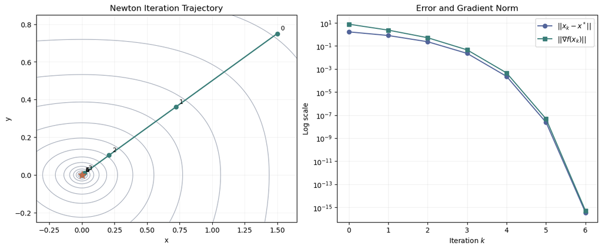

```python
x_grid = np.linspace(-0.35, 1.65, 320)
y_grid = np.linspace(-0.25, 0.85, 320)
X, Y = np.meshgrid(x_grid, y_grid)
Z = np.exp(X) - X + np.exp(2.0 * Y) - 2.0 * Y

fig, axes = plt.subplots(1, 2, figsize=(12, 4.9), constrained_layout=True)

levels = 2.0 + np.geomspace(1e-4, 8.0, 16)
axes[0].contour(X, Y, Z, levels=levels, colors="#9aa2b1", linewidths=0.8)
axes[0].plot(history[:, 0], history[:, 1], "o-", color="#397d78", linewidth=1.8)
axes[0].scatter([0.0], [0.0], marker="*", s=120, color="#c26b4a", zorder=4)
for k, point in enumerate(history):
    axes[0].annotate(str(k), point, xytext=(5, 5), textcoords="offset points", fontsize=9)
axes[0].set(
    title="Newton Iteration Trajectory",
    xlabel="x",
    ylabel="y",
)
axes[0].grid(alpha=0.15)

tiny = np.finfo(float).tiny
iterations = np.arange(len(history))
axes[1].semilogy(iterations, np.maximum(errors, tiny), "o-", color="#52649a", label=r"$||x_k-x^*||$")
axes[1].semilogy(iterations, np.maximum(gradient_norms, tiny), "s-", color="#397d78", label=r"$||\nabla f(x_k)||$")
axes[1].set(
    title="Error and Gradient Norm",
    xlabel="Iteration $k$",
    ylabel="Log scale",
)
axes[1].grid(True, which="both", alpha=0.2)
axes[1].legend()
plt.show()
```

#### 观察

当迭代点进入最小值邻域后，误差平方比趋于有限常数，误差曲线迅速下降。这对应 Newton 法的局部 Q-二次收敛。